# OI perception data explore

Louise Shepperd

2023-06-26

### Introduction

The research questions are as follows:

*RQ 2: What influence of written input are learners aware of regarding word learning?*

*2.1: What was the perceived influence of written input on their learning in the study?*

*2.2: What were participants’ beliefs around the importance of written input when learning new words more broadly?*

This document will explore each of these questions in turn.

### RQ 2.1 Perception of OI influence in the study

#### First notice OI

First of all, it was of interest to know whether or not people noticed the written forms, as some people mentioned durng piloting that they didn’t see the written words or noticed them midway through word learning.

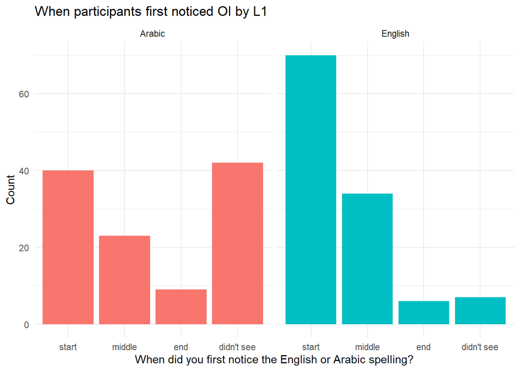

#### OI preference

The table and plots below offers a summary of the variables regarding learner perception of OI during the study.

Summary Statistics

| L1 Variable | Arabic N | Arabic Percent | English N | English Percent |
| --- | --- | --- | --- | --- |
| see_english | 114 |  | 117 |  |
| … difficult | 6 | 5.3% | 0 | 0% |
| … easier | 94 | 82.5% | 84 | 71.8% |
| … no_diff | 7 | 6.1% | 25 | 21.4% |
| … no_notice | 7 | 6.1% | 8 | 6.8% |
| see_arabic | 114 |  | 117 |  |
| … difficult | 23 | 20.2% | 22 | 18.8% |
| … easier | 51 | 44.7% | 3 | 2.6% |
| … no_diff | 26 | 22.8% | 82 | 70.1% |
| … no_notice | 14 | 12.3% | 10 | 8.5% |
| no_spell | 114 |  | 117 |  |
| … difficult | 70 | 61.4% | 49 | 41.9% |
| … easier | 25 | 21.9% | 14 | 12% |
| … no_diff | 17 | 14.9% | 44 | 37.6% |
| … no_notice | 2 | 1.8% | 10 | 8.5% |
| spelling.preference | 114 |  | 117 |  |
| … #N/A | 2 | 1.8% | 0 | 0% |
| … in_arabic | 15 | 13.2% | 3 | 2.6% |
| … in_english | 95 | 83.3% | 99 | 84.6% |
| … no_OI | 2 | 1.8% | 15 | 12.8% |

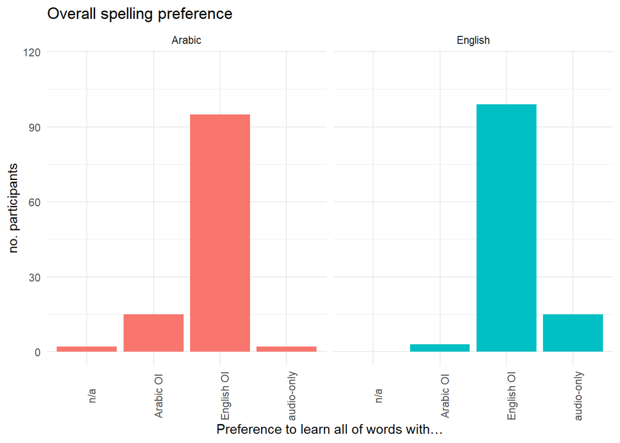

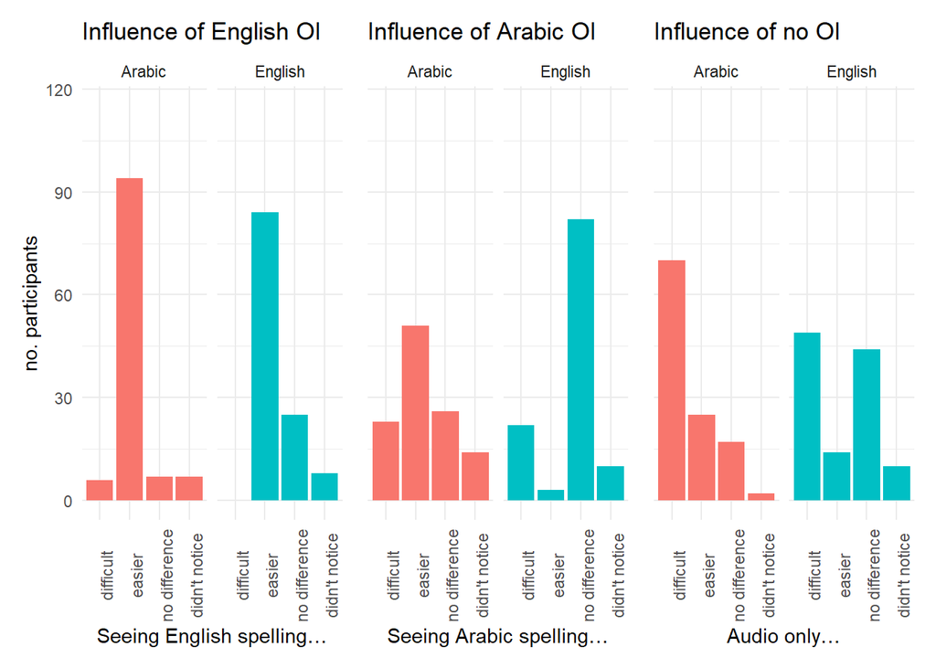

In order to see how L1 Arabic preferences related to L2 English experience, they were plotted against proficiency test score.

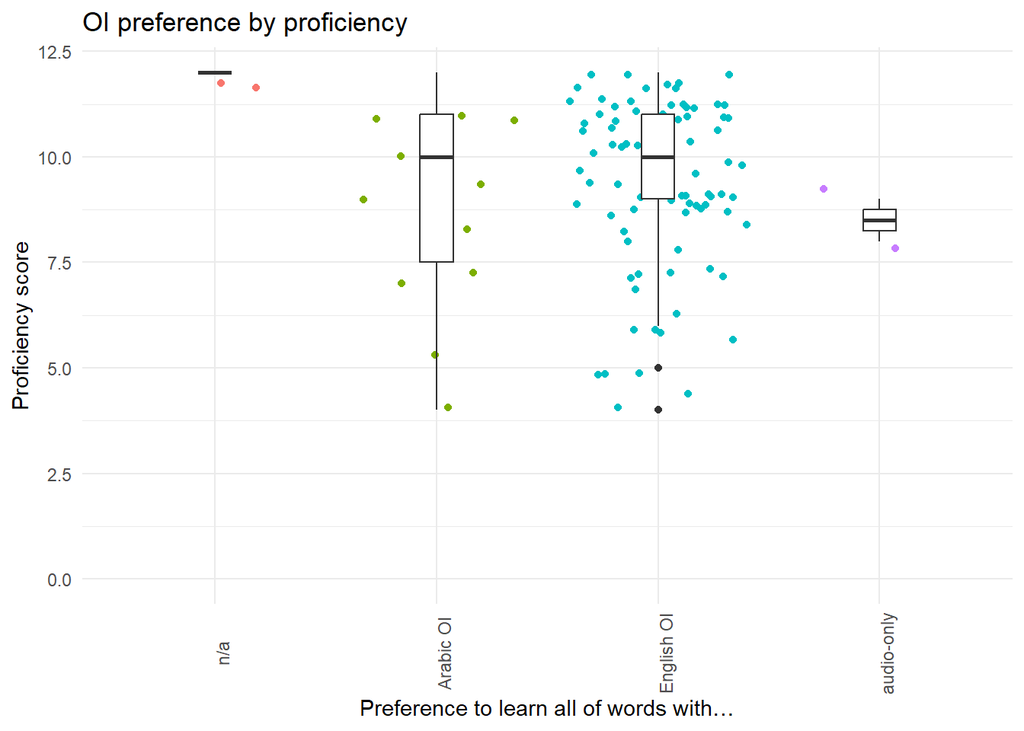

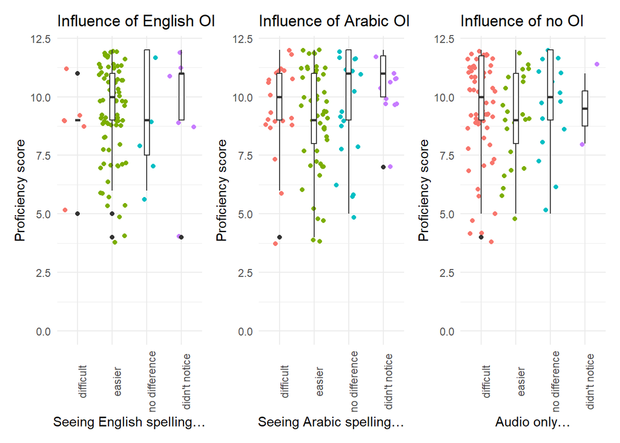

### RQ 2.2 Perception of OI importance in general

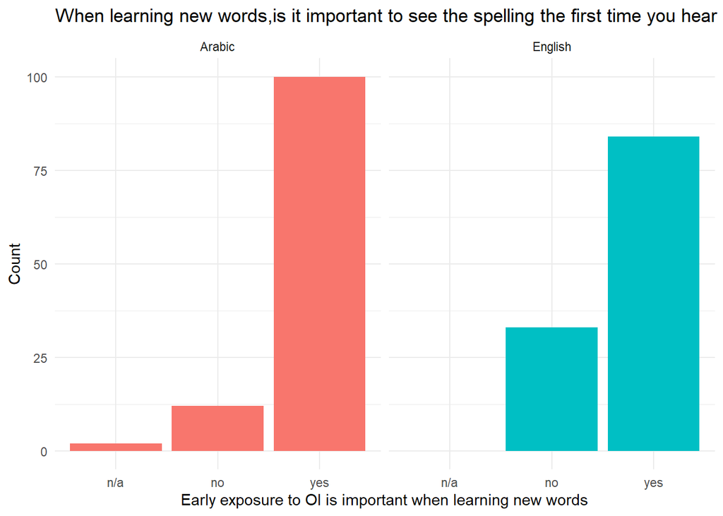